# Reproducible Research: Peer Assessment 1

## Loading and preprocessing the data

The first step is simply unzipping the file and reading it as a csv. Then, we load in the required package and transform the data

```r
unzip(zipfile = "activity.zip")
data <- read.csv("activity.csv")
library(ggplot2)
steps.ds <- tapply(data$steps, data$date, FUN = sum, na.rm = TRUE)
```

## What is mean total number of steps taken per day?

Now, we want to visaulize the data and find the mean and median.

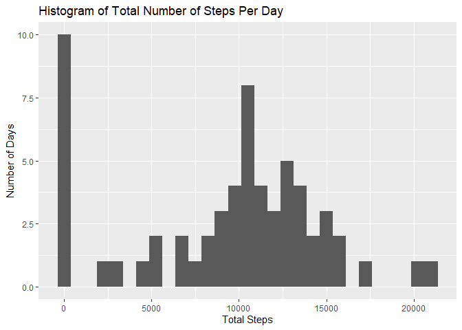

```r
qplot(steps.ds, binwidth = 750, xlab = "Total Steps", ylab = "Number of Days", main = "Histogram of Total Number of Steps Per Day")
```

```r
daymean <- mean(steps.ds, na.rm = TRUE)
daymedian <- median(steps.ds, na.rm = TRUE)
```

Therefore, our mean is 9354.2295082 and our median is 10395.

## What is the average daily activity pattern?

Next, we want to figure out which 5-minute interval, on average across all the days in the dataset, contains the maximum number of steps.

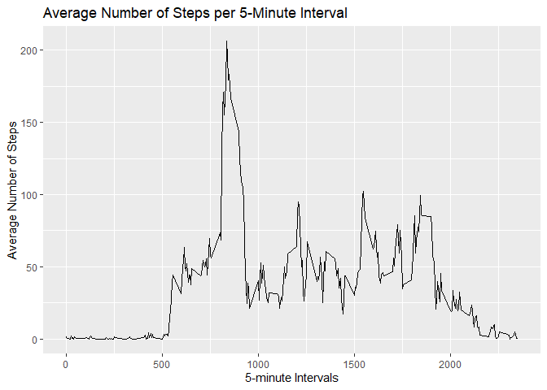

```r
data.avg <- aggregate(x = list(steps = data$steps), by = list(interval = data$interval), FUN = mean, na.rm = TRUE)
ggplot(data = data.avg, aes(x = interval, y = steps)) +
      geom_line() +
      xlab("5-minute Intervals") +
      ylab("Average Number of Steps") +
      ggtitle("Average Number of Steps per 5-Minute Interval")
```

```r
max <- data.avg[which.max(data.avg$steps), ]
table(max)
```

```
##         steps
## interval 206.169811320755
##      835                1
```

```r
na.total <- is.na(data$steps)
table(na.total)
```

```
## na.total
## FALSE  TRUE
## 15264  2304
```

```r
fill.na <- function(steps, interval) {
  fill <- NA
  if (!is.na(steps))
    fill <- c(steps) else fill <- (data.avg[data.avg$interval == interval, "steps"])
    return(fill)
}
fill.data <- data
fill.data$steps <- mapply(fill.na, fill.data$steps, fill.data$interval)

fill.natotal <- is.na(fill.data$steps)
table(fill.natotal)
```

```
## fill.natotal
## FALSE
## 17568
```

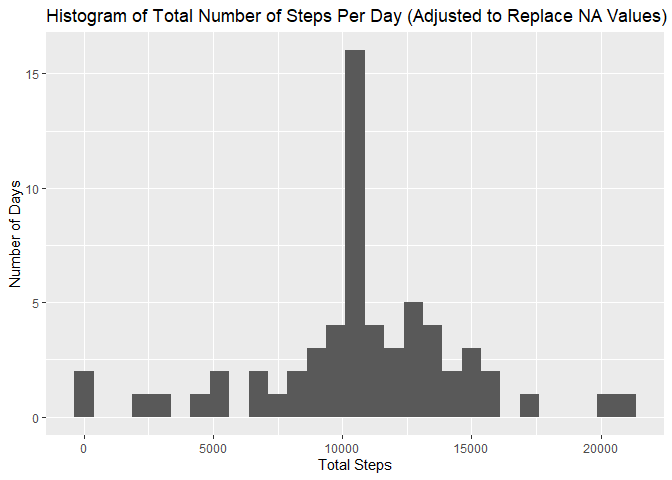

```r
fillsteps.ds <- tapply(fill.data$steps, fill.data$date, FUN = sum)
qplot(fillsteps.ds, binwidth = 750, xlab = "Total Steps", ylab = "Number of Days", main = "Histogram of Total Number of Steps Per Day (Adjusted to Replace NA Values)")
```

```r
fillmean <- mean(fillsteps.ds)
fillmedian <- median(fillsteps.ds)
```

## Are there differences in activity patterns between weekdays and weekends?

Lastly, we want to check activity patterns in weekdays and weekends. The first step is to set the dates as weekdays and then classify them as either weekdays or weekend. Then, we find the means and make a time series plot comparing the two.

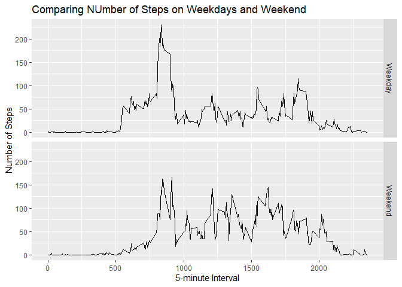

```r
fill.data$weekdays <- weekdays(as.Date(fill.data$date))
fill.data$daytype <- ifelse(fill.data$weekdays %in% c("Saturday", "Sunday"), "Weekend", "Weekday")

weekday.avg <- aggregate(steps ~ interval + daytype, data = fill.data, mean)
ggplot(weekday.avg, aes(interval, steps)) + geom_line() + facet_grid(daytype ~ .) +
  xlab("5-minute Interval") +
  ylab("Number of Steps") +
  ggtitle("Comparing NUmber of Steps on Weekdays and Weekend")
```